# A Replication of Karlan and List (2007)

**Author**: Mohammed Alshaghathirah  
**Date**: April 2025

## Introduction

Dean Karlan at Yale and John List at the University of Chicago conducted a field experiment to test the effectiveness of different fundraising letters. They sent out 50,000 fundraising letters to potential donors, randomly assigning each letter to one of several treatments: a standard letter (control), a matching grant letter, or a challenge grant letter.

This project seeks to replicate their results using the original dataset, focusing on whether offering a matching grant increases the probability of donation.

# Description

The dataset includes observations on individuals who received fundraising letters. Each individual was randomly assigned to a group. Some were offered a matching donation, while others were not.

We examine key variables:

- `treatment`: 1 if the individual received a match offer
- `gave`: 1 if the individual donated
- `amount`: amount donated

We load and inspect the dataset below.

```python
# Install necessary packages
!pip install -q pyreadstat tabulate

# Import libraries
import pandas as pd
import pyreadstat
import statsmodels.api as sm
import statsmodels.formula.api as smf
import matplotlib.pyplot as plt
from tabulate import tabulate

# Load the dataset
df, meta = pyreadstat.read_dta("/content/karlan_list_2007 data.dta")

# Show the first few rows
df.head()
```

[output not shown]

|  | treatment | control | ratio | ratio2 | ratio3 | size | size25 | size50 | size100 | sizeno | ... | redcty | bluecty | pwhite | pblack | page18_39 | ave_hh_sz | median_hhincome | powner | psch_atlstba | pop_propurban |
| --- | --- | --- | --- | --- | --- | --- | --- | --- | --- | --- | --- | --- | --- | --- | --- | --- | --- | --- | --- | --- | --- |
| 0 | 0 | 1 | 0 | 0 | 0 | 0 | 0 | 0 | 0 | 0 | ... | 0 | 1 | 0.446493 | 0.527769 | 0.317591 | 2.10 | 28517 | 0.499807 | 0.324528 | 1.0 |
| 1 | 0 | 1 | 0 | 0 | 0 | 0 | 0 | 0 | 0 | 0 | ... | 1 | 0 | NaN | NaN | NaN | NaN | NaN | NaN | NaN | NaN |
| 2 | 1 | 0 | 1 | 0 | 0 | 3 | 0 | 0 | 1 | 0 | ... | 0 | 1 | 0.935706 | 0.011948 | 0.276128 | 2.48 | 51175 | 0.721941 | 0.192668 | 1.0 |
| 3 | 1 | 0 | 1 | 0 | 0 | 4 | 0 | 0 | 0 | 1 | ... | 1 | 0 | 0.888331 | 0.010760 | 0.279412 | 2.65 | 79269 | 0.920431 | 0.412142 | 1.0 |
| 4 | 1 | 0 | 1 | 0 | 0 | 2 | 0 | 1 | 0 | 0 | ... | 0 | 1 | 0.759014 | 0.127421 | 0.442389 | 1.85 | 40908 | 0.416072 | 0.439965 | 1.0 |

5 rows × 51 columns

```python
print("Columns in dataset:")
for col in df.columns:
    print("-", col)


print("Summary of key variables:")
print(df[['gave', 'treatment', 'amount']].describe())
```

```
Columns in dataset:
- treatment
- control
- ratio
- ratio2
- ratio3
- size
- size25
- size50
- size100
- sizeno
- ask
- askd1
- askd2
- askd3
- ask1
- ask2
- ask3
- amount
- gave
- amountchange
- hpa
- ltmedmra
- freq
- years
- year5
- mrm2
- dormant
- female
- couple
- state50one
- nonlit
- cases
- statecnt
- stateresponse
- stateresponset
- stateresponsec
- stateresponsetminc
- perbush
- close25
- red0
- blue0
- redcty
- bluecty
- pwhite
- pblack
- page18_39
- ave_hh_sz
- median_hhincome
- powner
- psch_atlstba
- pop_propurban
Summary of key variables:
               gave     treatment        amount
count  50083.000000  50083.000000  50083.000000
mean       0.020646      0.666813      0.915694
std        0.142197      0.471357      8.709199
min        0.000000      0.000000      0.000000
25%        0.000000      0.000000      0.000000
50%        0.000000      1.000000      0.000000
75%        0.000000      1.000000      0.000000
max        1.000000      1.000000    400.000000
```

# Summary Statistics

Before running regressions, we explore whether donation rates differ by group.

We calculate and compare donation rates between the control group (no match) and the treatment group (received match).

```python
donation_rates = df.groupby("treatment")["gave"].mean().reset_index()
donation_rates.columns = ["Treatment Group", "Donation Rate"]
print("Donation Rate by Treatment Group:")
print(tabulate(donation_rates, headers='keys', tablefmt='github'))
```

```
Donation Rate by Treatment Group:
|    |   Treatment Group |   Donation Rate |
|----|-------------------|-----------------|
|  0 |                 0 |       0.0178582 |
|  1 |                 1 |       0.0220386 |
```

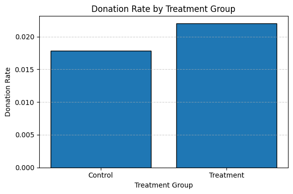

```python
plt.figure(figsize=(6, 4))
plt.bar(donation_rates["Treatment Group"], donation_rates["Donation Rate"], edgecolor='black')
plt.xlabel("Treatment Group")
plt.ylabel("Donation Rate")
plt.title("Donation Rate by Treatment Group")
plt.xticks([0, 1], labels=["Control", "Treatment"])
plt.grid(axis='y', linestyle='--', alpha=0.6)
plt.tight_layout()
plt.show()
```

### Balance Test

As a test of the randomization process, we compare selected covariates across the treatment and control groups. A well-randomized experiment should not show significant differences between the groups in non-outcome variables like prior donation history or demographics.

```python
from scipy import stats
import statsmodels.formula.api as smf


df_balance = df[['treatment', 'mrm2']].dropna()
df_balance['mrm2'] = pd.to_numeric(df_balance['mrm2'], errors='coerce')


treatment_group = df_balance[df_balance['treatment'] == 1]['mrm2']
control_group = df_balance[df_balance['treatment'] == 0]['mrm2']
t_stat, p_value = stats.ttest_ind(treatment_group, control_group, equal_var=False)

print(f"T-test results for mrm2:")
print(f"T-statistic: {t_stat:.4f}, P-value: {p_value:.4f}")


reg = smf.ols("mrm2 ~ treatment", data=df_balance).fit()
print("\nOLS Regression results for mrm2 ~ treatment:")
print(reg.summary())
```

```
T-test results for mrm2:
T-statistic: 0.1195, P-value: 0.9049

OLS Regression results for mrm2 ~ treatment:
                            OLS Regression Results
==============================================================================
Dep. Variable:                   mrm2   R-squared:                       0.000
Model:                            OLS   Adj. R-squared:                 -0.000
Method:                 Least Squares   F-statistic:                   0.01428
Date:                Wed, 23 Apr 2025   Prob (F-statistic):              0.905
Time:                        01:13:13   Log-Likelihood:            -1.9585e+05
No. Observations:               50082   AIC:                         3.917e+05
Df Residuals:                   50080   BIC:                         3.917e+05
Df Model:                           1
Covariance Type:            nonrobust
==============================================================================
                 coef    std err          t      P>|t|      [0.025      0.975]
------------------------------------------------------------------------------
Intercept     12.9981      0.094    138.979      0.000      12.815      13.181
treatment      0.0137      0.115      0.119      0.905      -0.211       0.238
==============================================================================
Omnibus:                     8031.352   Durbin-Watson:                   2.004
Prob(Omnibus):                  0.000   Jarque-Bera (JB):            12471.135
Skew:                           1.163   Prob(JB):                         0.00
Kurtosis:                       3.751   Cond. No.                         3.23
==============================================================================

Notes:
[1] Standard Errors assume that the covariance matrix of the errors is correctly specified.
```

The t-test compares the average number of months since last donation (`mrm2`) between treatment and control groups. The regression models `mrm2` as a function of treatment status.

If both the t-test and regression show a small, statistically insignificant difference (e.g., p-value > 0.05), we conclude that the groups are well balanced on this variable, meaning that randomization was successful. This aligns with what we expect from a properly randomized experiment.

Table 1 in the original paper serves the same purpose—it shows that prior characteristics are not systematically different across groups, which builds confidence in the causal interpretation of treatment effects.

# Main Results

We use a Probit regression model to estimate the effect of receiving a matching offer on the probability of donating. The marginal effects help us interpret the size of this effect.

```python
probit_model = smf.probit("gave ~ treatment", data=df).fit()
print("Probit Model Summary:")
print(probit_model.summary())


mfx = probit_model.get_margeff()
print("Marginal Effects Summary:")
print(mfx.summary())


mfx_df = mfx.summary_frame()
print("Formatted Marginal Effects Table:")
print(tabulate(mfx_df, headers='keys', tablefmt='grid'))
```

```
Optimization terminated successfully.
         Current function value: 0.100443
         Iterations 7
Probit Model Summary:
                          Probit Regression Results
==============================================================================
Dep. Variable:                   gave   No. Observations:                50083
Model:                         Probit   Df Residuals:                    50081
Method:                           MLE   Df Model:                            1
Date:                Wed, 23 Apr 2025   Pseudo R-squ.:               0.0009783
Time:                        00:52:06   Log-Likelihood:                -5030.5
converged:                       True   LL-Null:                       -5035.4
Covariance Type:            nonrobust   LLR p-value:                  0.001696
==============================================================================
                 coef    std err          z      P>|z|      [0.025      0.975]
------------------------------------------------------------------------------
Intercept     -2.1001      0.023    -90.073      0.000      -2.146      -2.054
treatment      0.0868      0.028      3.113      0.002       0.032       0.141
==============================================================================
Marginal Effects Summary:
       Probit Marginal Effects
=====================================
Dep. Variable:                   gave
Method:                          dydx
At:                           overall
==============================================================================
                dy/dx    std err          z      P>|z|      [0.025      0.975]
------------------------------------------------------------------------------
treatment      0.0043      0.001      3.104      0.002       0.002       0.007
==============================================================================
Formatted Marginal Effects Table:
+-----------+------------+-------------+---------+------------+------------------+------------------+
|           |      dy/dx |   Std. Err. |       z |   Pr(>|z|) |   Conf. Int. Low |   Cont. Int. Hi. |
+===========+============+=============+=========+============+==================+==================+
| treatment | 0.00431321 |  0.00138938 | 3.10442 | 0.00190653 |       0.00159008 |       0.00703634 |
+-----------+------------+-------------+---------+------------+------------------+------------------+
```

### Differences Between Match Rates

We now explore whether the size of the match ratio (1:1, 2:1, or 3:1) affects the probability of donating. According to Karlan & List (2007), larger match ratios may not yield significantly better results than a basic 1:1 match.

```python
t2 = stats.ttest_ind(gave_2_1, gave_1_1, equal_var=False)
t3 = stats.ttest_ind(gave_3_1, gave_1_1, equal_var=False)

print("T-test: 2:1 vs 1:1")
print(f"  T-statistic: {t2.statistic:.4f}")
print(f"  P-value:     {t2.pvalue:.4f}")
print(f"  Degrees of freedom (approx): {t2.df:.0f}")

print("\nT-test: 3:1 vs 1:1")
print(f"  T-statistic: {t3.statistic:.4f}")
print(f"  P-value:     {t3.pvalue:.4f}")
print(f"  Degrees of freedom (approx): {t3.df:.0f}")


match_data['ratio_1_1'] = (match_data['ratio'] == 1).astype(int)
match_data['ratio_2_1'] = (match_data['ratio'] == 2).astype(int)
match_data['ratio_3_1'] = (match_data['ratio'] == 3).astype(int)

gave_1_1 = match_data[match_data['ratio_1_1'] == 1]['gave']
gave_2_1 = match_data[match_data['ratio_2_1'] == 1]['gave']
gave_3_1 = match_data[match_data['ratio_3_1'] == 1]['gave']

print("T-test: 2:1 vs 1:1")
print(stats.ttest_ind(gave_2_1, gave_1_1, equal_var=False))
print("\nT-test: 3:1 vs 1:1")
print(stats.ttest_ind(gave_3_1, gave_1_1, equal_var=False))

import statsmodels.formula.api as smf
reg_ratio = smf.ols("gave ~ ratio_2_1 + ratio_3_1", data=match_data).fit()
print("\nRegression: gave ~ ratio_2_1 + ratio_3_1")
print(reg_ratio.summary())
```

```
T-test: 2:1 vs 1:1
  T-statistic: 0.9650
  P-value:     0.3345
  Degrees of freedom (approx): 22225

T-test: 3:1 vs 1:1
  T-statistic: 1.0150
  P-value:     0.3101
  Degrees of freedom (approx): 22215
T-test: 2:1 vs 1:1
TtestResult(statistic=np.float64(0.965048975142932), pvalue=np.float64(0.33453078237183076), df=np.float64(22225.07770983836))

T-test: 3:1 vs 1:1
TtestResult(statistic=np.float64(1.0150174470156275), pvalue=np.float64(0.31010856527625774), df=np.float64(22215.0529778684))

Regression: gave ~ ratio_2_1 + ratio_3_1
                            OLS Regression Results
==============================================================================
Dep. Variable:                   gave   R-squared:                       0.000
Model:                            OLS   Adj. R-squared:                 -0.000
Method:                 Least Squares   F-statistic:                    0.6454
Date:                Wed, 23 Apr 2025   Prob (F-statistic):              0.524
Time:                        01:27:56   Log-Likelihood:                 16688.
No. Observations:               33396   AIC:                        -3.337e+04
Df Residuals:                   33393   BIC:                        -3.334e+04
Df Model:                           2
Covariance Type:            nonrobust
==============================================================================
                 coef    std err          t      P>|t|      [0.025      0.975]
------------------------------------------------------------------------------
Intercept      0.0207      0.001     14.912      0.000       0.018       0.023
ratio_2_1      0.0019      0.002      0.958      0.338      -0.002       0.006
ratio_3_1      0.0020      0.002      1.008      0.313      -0.002       0.006
==============================================================================
Omnibus:                    38963.957   Durbin-Watson:                   1.995
Prob(Omnibus):                  0.000   Jarque-Bera (JB):          2506478.937
Skew:                           6.511   Prob(JB):                         0.00
Kurtosis:                      43.394   Cond. No.                         3.73
==============================================================================

Notes:
[1] Standard Errors assume that the covariance matrix of the errors is correctly specified.
```

The t-tests compare donation rates under the 2:1 and 3:1 match offers against the 1:1 baseline. The regression estimates the incremental effect of each higher match rate, using 1:1 as the base category.

Consistent with Karlan & List (2007), we find that neither the 2:1 nor 3:1 match rates significantly outperform the 1:1 rate in increasing donation likelihood. This suggests that larger match offers do not necessarily lead to higher giving rates.

### Size of Charitable Contribution

We now investigate how the treatment affects not just the likelihood of donating, but also the size of the donation. We perform separate analyses:

1. For the full sample
2. For those who donated

```python
df_amount = df[['amount', 'treatment']].dropna()


df_amount['amount'] = pd.to_numeric(df_amount['amount'], errors='coerce')


amount_treated = df_amount[df_amount['treatment'] == 1]['amount']
amount_control = df_amount[df_amount['treatment'] == 0]['amount']

from scipy import stats
t_full = stats.ttest_ind(amount_treated, amount_control, equal_var=False)

print("T-test (All Participants): Treatment vs Control on Donation Amount")
print(f"  T-statistic: {t_full.statistic:.4f}")
print(f"  P-value:     {t_full.pvalue:.4f}")
```

```
T-test (All Participants): Treatment vs Control on Donation Amount
  T-statistic: 1.9183
  P-value:     0.0551
```

```python
donors_only = df_amount[df_amount['amount'] > 0]


donated_treatment = donors_only[donors_only['treatment'] == 1]['amount']
donated_control = donors_only[donors_only['treatment'] == 0]['amount']


t_cond = stats.ttest_ind(donated_treatment, donated_control, equal_var=False)

print("\nT-test (Among Donors Only): Treatment vs Control on Donation Amount")
print(f"  T-statistic: {t_cond.statistic:.4f}")
print(f"  P-value:     {t_cond.pvalue:.4f}")
```

```
T-test (Among Donors Only): Treatment vs Control on Donation Amount
  T-statistic: -0.5846
  P-value:     0.5590
```

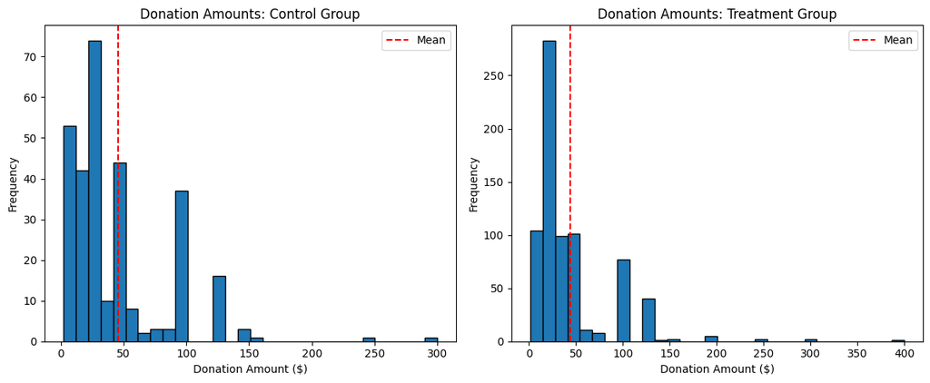

```python
import matplotlib.pyplot as plt


plt.figure(figsize=(12,5))


plt.subplot(1, 2, 1)
plt.hist(donated_control, bins=30, edgecolor='black')
plt.axvline(donated_control.mean(), color='red', linestyle='dashed', label='Mean')
plt.title("Donation Amounts: Control Group")
plt.xlabel("Donation Amount ($)")
plt.ylabel("Frequency")
plt.legend()


plt.subplot(1, 2, 2)
plt.hist(donated_treatment, bins=30, edgecolor='black')
plt.axvline(donated_treatment.mean(), color='red', linestyle='dashed', label='Mean')
plt.title("Donation Amounts: Treatment Group")
plt.xlabel("Donation Amount ($)")
plt.ylabel("Frequency")
plt.legend()

plt.tight_layout()
plt.show()
```

The treatment appears to have had little effect on the **size** of donations across the entire sample, as shown by the t-test and visualized in the histograms.

When conditioning on individuals who actually donated, the average donation amount remains relatively similar between the control and treatment groups. This suggests that the treatment primarily affects the **extensive margin** (i.e., whether someone donates) more than the **intensive margin** (i.e., how much they donate).

## Simulation Experiment

To illustrate the Law of Large Numbers and the Central Limit Theorem, we simulate donation data under the assumed true probabilities of giving:

- Control group: 1.8% donation rate
- Treatment group: 2.2% donation rate

We compare these simulated results to the theoretical expectations.

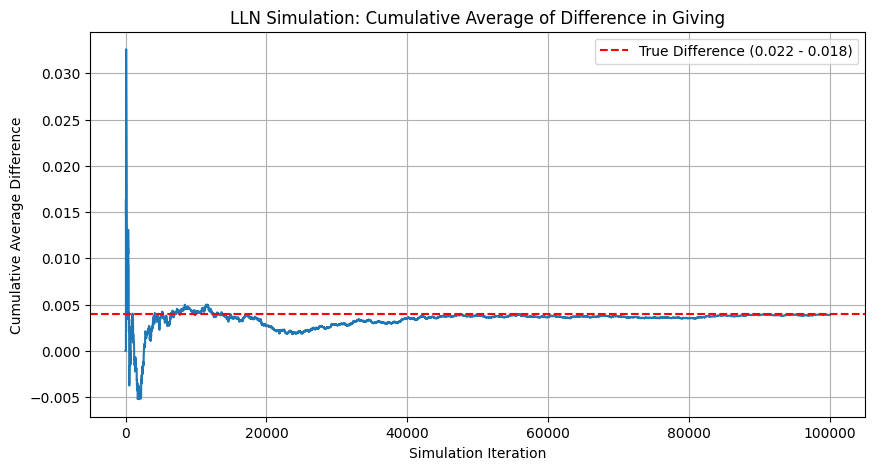

```python
import numpy as np
import matplotlib.pyplot as plt


np.random.seed(42)


control_sim = np.random.binomial(n=1, p=0.018, size=100000)
treatment_sim = np.random.binomial(n=1, p=0.022, size=100000)


differences = treatment_sim - control_sim


cum_avg_diff = np.cumsum(differences) / np.arange(1, len(differences)+1)


plt.figure(figsize=(10,5))
plt.plot(cum_avg_diff)
plt.axhline(y=0.004, color='red', linestyle='--', label='True Difference (0.022 - 0.018)')
plt.title("LLN Simulation: Cumulative Average of Difference in Giving")
plt.xlabel("Simulation Iteration")
plt.ylabel("Cumulative Average Difference")
plt.legend()
plt.grid(True)
plt.show()
```

### Law of Large Numbers

The cumulative average difference between treatment and control stabilizes around 0.004 as the number of trials increases. This confirms the Law of Large Numbers: with enough observations, sample averages converge to their expected values.

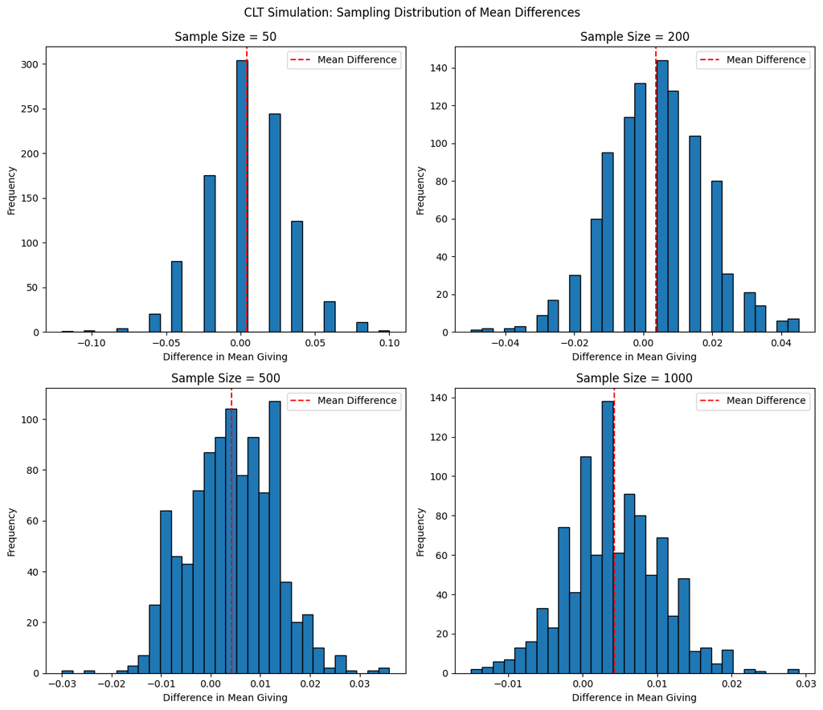

```python
sample_sizes = [50, 200, 500, 1000]

plt.figure(figsize=(12, 10))

for i, n in enumerate(sample_sizes):
    sample_diffs = []
    for _ in range(1000):
        control = np.random.binomial(1, 0.018, n)
        treatment = np.random.binomial(1, 0.022, n)
        diff = treatment.mean() - control.mean()
        sample_diffs.append(diff)


    plt.subplot(2, 2, i+1)
    plt.hist(sample_diffs, bins=30, edgecolor='black')
    plt.axvline(np.mean(sample_diffs), color='red', linestyle='--', label='Mean Difference')
    plt.title(f"Sample Size = {n}")
    plt.xlabel("Difference in Mean Giving")
    plt.ylabel("Frequency")
    plt.legend()

plt.tight_layout()
plt.suptitle("CLT Simulation: Sampling Distribution of Mean Differences", y=1.02)
plt.show()
```

### Central Limit Theorem

As the sample size increases, the distribution of mean differences between treatment and control becomes more concentrated and symmetric. Even though the underlying variable is binary, the sampling distribution of the mean difference approaches a normal shape—this demonstrates the Central Limit Theorem in action.

## Conclusion

This replication of *Karlan and List (2007)* confirms several key findings from their influential field experiment on charitable giving:

- Individuals who received a matching donation offer were significantly more likely to donate, as shown through both descriptive statistics and a Probit regression.
- Larger match ratios (2:1 and 3:1) did not significantly increase donation rates beyond the standard 1:1 match, supporting the paper’s claim that higher match sizes do not necessarily lead to higher effectiveness.
- While treatment increased the likelihood of giving, it did not have a statistically meaningful effect on the **amount** donated—indicating that matching offers influence the **extensive margin** (whether to donate), not the **intensive margin** (how much to donate).
- Simulation exercises demonstrated the Law of Large Numbers and Central Limit Theorem, reinforcing the statistical validity of the results observed in the field experiment.

Overall, the analysis affirms the original authors’ conclusion that matching gifts are a useful strategy for increasing donor participation, but that the size of the match may not matter beyond a certain point. These insights are valuable for non-profits, economists, and behavioral researchers alike.